# Counting Your Customers: Module 2 Practice Project

Your Name, Your Uniqname

# Directions

This project builds the model in

> Fader, P. S., Hardie, B. G. S., & Lee, K. L. (2005). “Counting Your Customers” the Easy Way: An Alternative to the Pareto/NBD Model. *Marketing Science*, 24(2), 275–284.

It has one task for each video of the module. The math each task needs is worked out for you, and each task ends with a check against a known answer. The practice exam asks about this document, the same way the real exam asks about your project.

This document is also turn-in 2.6, worth 1 point for completion. Each task has a chunk with a function for you to write and code that checks it. Write the function, and write your answers after each **Answer:**. Knit to HTML and upload the `.html` file to Canvas. Until you write a function, its check fails or shows an error. That is expected.

# The model and the data

CDNOW was an online music store. The data are 2,357 customers who made their first purchase in early 1997. For each customer we know

- `T`: weeks from their first purchase to the end of the 39-week calibration period,
- `x`: the number of repeat purchases in that period,
- `t_x`: the week of their last repeat purchase (0 if `x` is 0),
- `x_star`: the number of purchases in the next 39 weeks.

```r
cdnow <- read.csv("../../data/cdnow.csv")
head(cdnow)
```

```
##   id        T x       t_x x_star
## 1  1 38.85714 2 30.428571      1
## 2  2 38.85714 1  1.714286      0
## 3  3 38.85714 0  0.000000      0
## 4  4 38.85714 0  0.000000      0
## 5  5 38.85714 0  0.000000      0
## 6  6 38.85714 7 29.428571      8
```

The paper’s model (section 3) has four parts:

1. While active, a customer’s purchases form a Poisson process with rate $\lambda$, so the gaps between purchases are $\text{Exp}(\lambda)$.
2. Rates vary across customers: $\lambda \sim \text{Gamma}(r, \alpha)$, with $\alpha$ a rate.
3. After each purchase, the customer quits with probability $p$.
4. Quitting probabilities vary across customers: $p \sim \text{Beta}(a, b)$, independent of $\lambda$.

We use the paper’s estimates (Table 2), in weeks:

```r
r <- 0.243
alpha <- 4.414
a <- 0.793
b <- 2.426
```

# Part A: Inversion

Let $J$ be the purchase after which a customer quits, so $P(J = j) = p(1 - p)^{j - 1}$ for $j = 1, 2, \ldots$ The customer stays after each of the first $j$ purchases with probability $(1 - p)^j$, so $F(j) = 1 - (1 - p)^j$. The quantile function $Q(u)$ is the smallest integer $j$ with $F(j) \ge u$.

## Task A

1. Show that
   $$Q(u) = \left\lceil
   \frac{\log(1 - u)}{\log(1 - p)} \right\rceil.$$
   Hint: solve $F(j) \ge u$ for $j$, and remember that $\log(1 - p) < 0$.

**Answer:**

2. Write `rquit(n, p)`, which draws $J$ by inversion. Since $1 - U$ is also uniform, you can use $\log U$ in place of $\log(1 - U)$. The code below checks 10,000 draws with $p = 0.3$ with a QQ plot against `qgeom(u, p) + 1`. (R’s geometric counts the failures before the first success, so it starts at 0. `geom_qq` calls the quantile function with an argument named `p`, which here is the quantile level, not the quitting probability.)

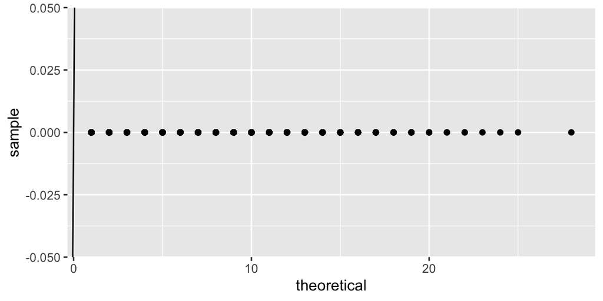

```r
rquit <- function(n, p) { rep(0, n) }

set.seed(20261015)
ggplot(tibble(sample = rquit(10000, 0.3)), aes(sample = sample)) +
  geom_qq(distribution = function(p) qgeom(p, 0.3) + 1) +
  geom_abline(intercept = 0, slope = 1)
```

# Part B: Mixtures

Now let $p$ vary across customers: draw $p \sim \text{Beta}(a, b)$, then $J \mid p$. Averaging $P(J > j \mid p) = (1 - p)^j$ over the Beta gives the tail of the mixture,
$$P(J
> j) = \text{E}\left((1 - p)^j\right) = \frac{B(a, b + j)}{B(a,
b)},$$
where $B$ is the beta function (`beta` in R). For large $j$ this behaves like a constant times $j^{-a}$, a power law. Since $a < 1$, $\text{E}\left(J\right)$ is infinite.

## Task B

Write `rquit_mix(n)`, which draws $J$ from the mixture using your `rquit`. (`rquit` works with a vector `p`, one value per draw.) The code below compares the fraction of 10,000 draws with $J > j$ to the formula for $j = 1$, 10 and 100, then reports the mean and the largest draw.

```r
rquit_mix <- function(n) { rep(1, n) }

set.seed(20261015)
J <- rquit_mix(10000)
j <- c(1, 10, 100)
rbind(simulated = sapply(j, function(k) mean(J > k)),
      exact = beta(a, b + j) / beta(a, b))
```

```
##                [,1]      [,2]       [,3]
## simulated 0.0000000 0.0000000 0.00000000
## exact     0.7536502 0.2668145 0.04980363
```

```r
c(mean = mean(J), max = max(J))
```

```
## mean  max
##    1    1
```

Why can’t you check the mean of $J$ the way you checked the tails?

**Answer:**

# Part C: Accept-reject

Suppose we had no `rbeta`. We want draws from $f(p) = p^{a - 1}(1 - p)^{b - 1} / B(a, b)$ with $a = 0.793$ and $b = 2.426$. Since $a < 1$, $f(p) \to \infty$ as $p \to 0$, so no $c$ makes $c \cdot 1 \ge f(p)$ and a $U(0, 1)$ candidate cannot work.

Use the candidate density $g(p) = a p^{a - 1}$ on $(0, 1)$ instead. Its CDF is $p^a$, so we can draw from it by inversion, as $U^{1/a}$. Then
$$\frac{f(p)}{g(p)} = \frac{(1 - p)^{b -
1}}{a B(a, b)} \le \frac{1}{a B(a, b)} = c,$$
because $b > 1$ makes $(1 - p)^{b-1} \le 1$. Dividing by $c$, we accept a candidate $Y$ when $U \le (1 - Y)^{b - 1}$.

## Task C

Write `rbeta_ar(n)`, which proposes `n` candidates and returns the accepted ones. The code below checks the accepted draws from 10,000 candidates with a QQ plot against `qbeta`, and reports the acceptance rate with a 95% confidence interval next to $1/c$.

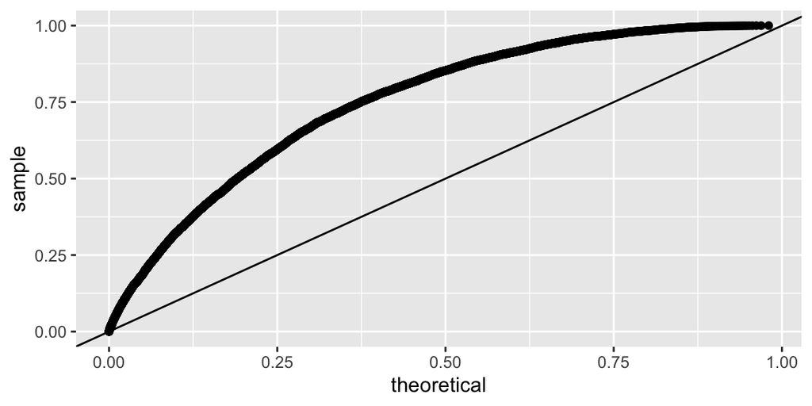

```r
rbeta_ar <- function(n) { runif(n) }

set.seed(20261015)
p_draws <- rbeta_ar(10000)

ggplot(tibble(sample = p_draws), aes(sample = sample)) +
  geom_qq(distribution = qbeta, dparams = list(shape1 = a, shape2 = b)) +
  geom_abline(intercept = 0, slope = 1)
```

```r
accepted <- length(p_draws)
c(rate = accepted / 10000, prop.test(accepted, 10000)$conf.int, one_over_c = a * beta(a, b))
```

```
##       rate                       one_over_c
##  1.0000000  0.9995213  1.0000000  0.4754463
```

**Checkpoint:** put the QQ plot on screen.

Does your interval contain $1/c$?

**Answer:**

# Part D: The purchase process

A customer’s purchase times are drawn one after another: each is the one before plus an $\text{Exp}(\lambda)$ gap, and after each purchase the customer quits with probability $p$.

## Task D

Write `purchases(lambda, p, t)`, which returns the purchase times of one active customer over $t$ weeks. Stop when the next time passes $t$ or the customer quits.

The code below simulates the data set: for each real customer it draws $\lambda$ and $p$, and counts their purchases over their own `T`. It compares the numbers of customers with 0, 1, …, 6, and 7 or more repeat purchases with the real data (the paper’s Figure 2). `mapply` calls the function once per customer, pairing the $i$th `lambda`, `p` and `T`.

```r
purchases <- function(lambda, p, t) { c() }

set.seed(20261015)
lambda <- rgamma(nrow(cdnow), r, alpha)
p <- rbeta(nrow(cdnow), a, b)
simulated <- mapply(function(l, q, t) length(purchases(l, q, t)), lambda, p, cdnow$T)
rbind(real = table(pmin(cdnow$x, 7)), simulated = table(pmin(simulated, 7)))
```

```
##              0    1    2    3    4    5    6    7
## real      1411  439  214  100   62   38   29   64
## simulated 2357 2357 2357 2357 2357 2357 2357 2357
```

How many of your simulated customers made no repeat purchase? The real data has 1,411.

**Answer:**

# Part E: Gibbs sampling

For one customer with history $(x, t_x, T)$, the posterior of $(\lambda, p)$ is the likelihood in the paper’s equation (3) times the two priors, known only up to a constant. The likelihood has two terms because the customer either was still active at $T$ or quit right after their last purchase.

Add a variable $Z$ for which case holds, with $Z = 1$ meaning still active. Given $Z$, the full conditionals are standard distributions:
$$\lambda \mid Z \sim \text{Gamma}\big(r + x, \;
\alpha + (T \text{ if } Z = 1, \text{ else } t_x)\big), \qquad
p \mid Z \sim \text{Beta}(a + 1 - Z, \; b + x - 1 + Z),$$
and, comparing the two terms of the likelihood,
$$P(Z = 1 \mid \lambda, p) = \frac{(1 - p)
e^{-\lambda (T - t_x)}}{p + (1 - p) e^{-\lambda (T - t_x)}}$$
when $x > 0$. A customer with $x = 0$ has made no repeat purchase to quit after, so $Z = 1$.

For a check, integrating $\lambda$ and $p$ out of each term against the priors gives the probability the customer is still active in closed form:
$$P(Z = 1 \mid x, t_x, T) = \left[1 +
\frac{a}{b + x - 1}\left(\frac{\alpha + T}{\alpha + t_x}\right)^{r +
x}\right]^{-1}.$$

## Task E

Write `gibbs_customer(x, t_x, T, k)`, which cycles through $Z$, $\lambda$ and $p$ for `k` iterations and returns the draws. The code below runs it for customer 1, with $x = 2$, $t_x = 30.43$ and $T = 38.86$, for 5,000 iterations. It makes a trace plot of $\lambda$, drops the first 500 draws, and compares the estimated probability that customer 1 is still active with the closed form.

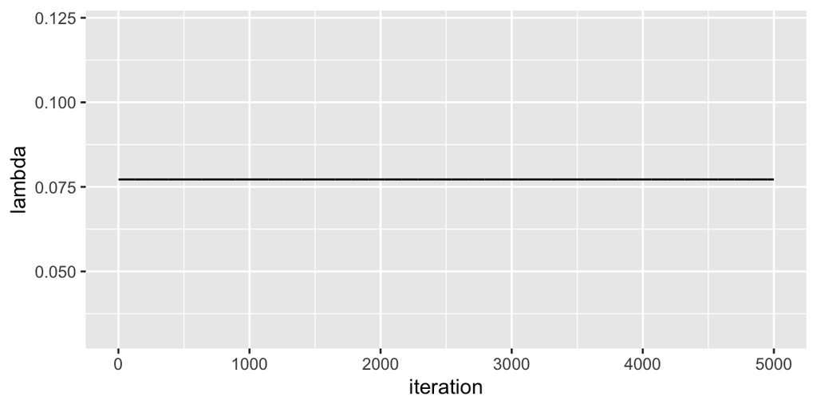

```r
gibbs_customer <- function(x, t_x, T, k) {
  lambda <- (x + 1) / T
  p <- 0.5
  z <- 1
  draws <- matrix(NA, k, 3, dimnames = list(NULL, c("lambda", "p", "active")))
  for (i in 1:k) {
    # draw z given lambda and p

    # draw lambda given z

    # draw p given z

    draws[i, ] <- c(lambda, p, z)
  }
  draws
}
set.seed(20261015)
chain <- gibbs_customer(2, 30.43, 38.86, 5000)

tibble(iteration = 1:5000, lambda = chain[, "lambda"]) |>
  ggplot(aes(iteration, lambda)) + geom_line()
```

```r
post <- chain[-(1:500), ]
c(gibbs = mean(post[, "active"]),
  exact = 1 / (1 + a / (b + 1) * ((alpha + 38.86) / (alpha + 30.43))^(r + 2)))
```

```
##     gibbs     exact
## 1.0000000 0.7265786
```

**Checkpoint:** put the trace plot on screen.

Do the Gibbs and exact probabilities agree?

**Answer:**

# What the model predicts

The Gibbs sampler gives draws of $(\lambda, p, Z)$ for any customer. Running it for each of the 214 customers with $x = 2$, and simulating the next 39 weeks with `purchases` for every draw with $Z = 1$, predicts 1.04 purchases per customer in the holdout period. These customers made 1.39. The paper’s equation (10) computes the same prediction without simulation, and it also gives 1.04.